# SPSS Tutorial 04

@ Ruhil

2017-08-30

# 1 Two-group t-tests

If we have two groups and the outcome of interest is a scale (interval/ratio) variable, the t-test is commonly used to test whether the outcome is statistically significantly different for the two groups. In SPSS, we can do this quite easily. Let us see how such a test can be conducted with, for example, the hs2 data (high-school and beyond data). Let us assume we are interested in testing whether math scores differ, on average, between male and female students.

Before we run this test, though, we’ll have to keep an eye on the $n$ for each group, as well as their respective standard deviations, and also test for normality. Let us test for normality first.

## 1.1 Normality testing

We will use `Explore` to run the test.

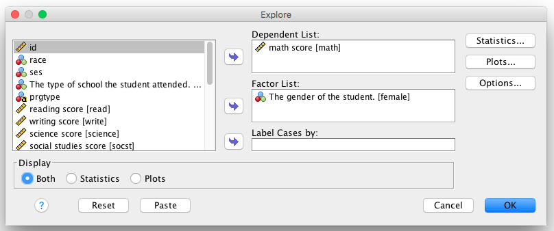

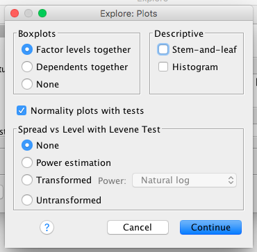

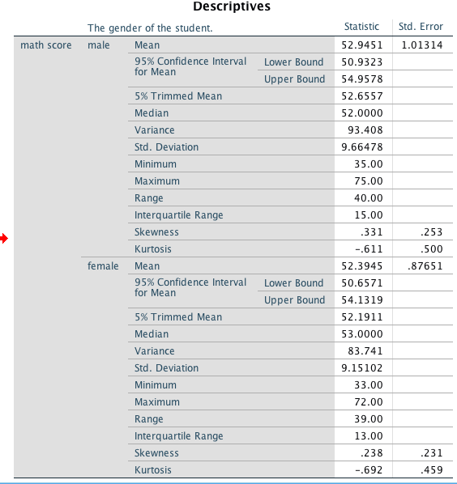

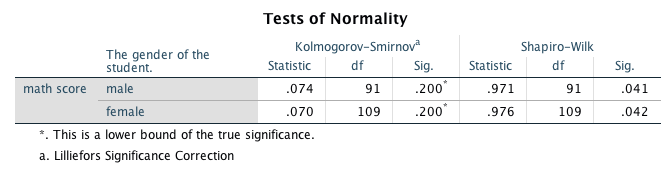

Look at the p-values in the Shapiro-Wilk test; we have to reject the Null hypothesis here. That amounts to saying the data are not normally distributed. Now, most people would transform the math scores by taking the natural logarithm. This usually works to normalize a distribution. If you do this and then re-run the normality tests you will see that now the Null hypothesis of normality is not rejected.

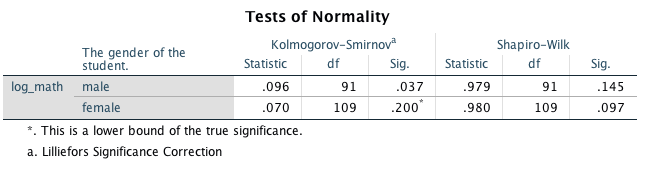

Note the high p-values; we can now proceed to run the t-test using `log_math`. When you do so, you will find no statistically significant difference between the two groups in math achievement.

### 1.1.1 Video Guide

[figure not shown]

## 1.2 The Independent Samples t-test

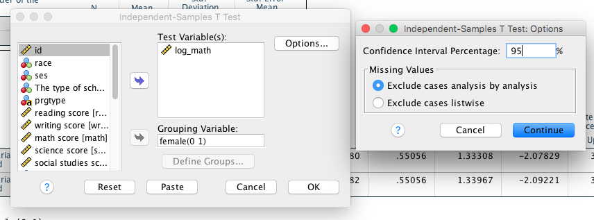

### 1.2.1 Video Guide

[figure not shown]

# 2 Paired Samples t-test

With paired samples, we have two groups that are “otherwise identical”. In one sense, thinking of the same units measured twice is a classic example of what paired sample represent. One data-set we have is the `STAR Data`. This was an [experiment in TN](https://dataverse.harvard.edu/dataset.xhtml?persistentId=hdl:1902.1/10766). We have students followed across multiple grades, with a host of other information about their classroom, their teacher, their demographics, and so on. Given these data (available from the course website), we could ask if student’s reading or mathematics performance has changed over time. In SPSS this would be done as follows:

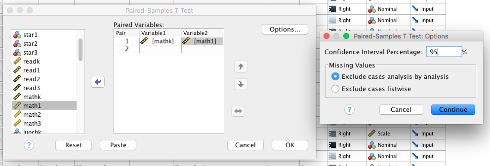

Of course, the same rules apply: The distribution must be normal, etc. but we need not worry about equal or unequal variances (since the test is really about differences between the outcome at time 1 versus time 2).

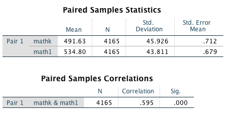

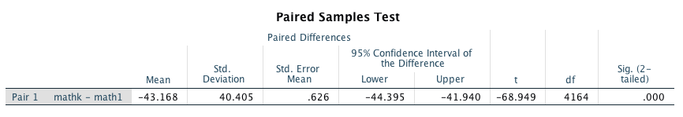

## 2.1 Video Guide

[figure not shown]